# Assignment_Week2

Hangsoo Jeong

9/15/2020

For the second assignment, I’ll be using the following libraries.

```r
library(tidyverse)
```

```r
library(ggplot2)
```

Also, the person-level dataset I created for the last assignment.

```r
person_data <- read_csv("people.csv")
```

## The continuous variables in the previous dataset.

There were three continuous variables in my person-level dataset in Massachusetts from the 1-year American Community Survey Sample from 2018.

1. Income (PINCP) (continuous)
2. Work hours per week (WKHP) (continuous)
3. Travel time to work (JWMNP) (continuous)

For each continuous variable, I will calculate the sample mean, the sample standard deviation, the 95-percent confidence interval for the population mean, and the interquartile range for each continuous variable. Also, I will create a histogram to illustrate the distribution of each variable.

## The Summary statistics of the income data.

First, the income. The Summary statistics of the income are as below.

```r
PINCP_summary <- summary(person_data$PINCP)
PINCP_summary
```

```
##    Min. 1st Qu.  Median    Mean 3rd Qu.    Max.
##   -4400   26700   51000   72962   88400 1353400
```

# The mean of the income data.

The mean of the income is 72961.97 dollars as below.

```r
PINCP_summary["Mean"]
```

```
##     Mean
## 72961.97
```

# The standard deviation of the income data.

Here is the standard deviation of the income, and its value is 88111.95 dollars.

```r
sd(person_data$PINCP)
```

```
## [1] 88111.95
```

# The 95-percent confidence interval for the income data.

I created a one-sample t-test to get a 95-percent confidence interval for the population mean.

```r
conf_int <- t.test(person_data$PINCP)

conf_int
```

```
##
##  One Sample t-test
##
## data:  person_data$PINCP
## t = 151.43, df = 33440, p-value < 2.2e-16
## alternative hypothesis: true mean is not equal to 0
## 95 percent confidence interval:
##  72017.56 73906.38
## sample estimates:
## mean of x
##  72961.97
```

So, based on the data above, the 95-percent confidence interval for the income is from 72017.56 dollars to 73906.38 dollars.

# The interquartile range of the income data.

The interquartile range is from the first quartile to the third quartile of data.

```r
PINCP_summary["1st Qu."]
```

```
## 1st Qu.
##   26700
```

```r
PINCP_summary["3rd Qu."]
```

```
## 3rd Qu.
##   88400
```

Therefore, the interquartile range of the income is from 26700 dollars to 88400 dollars.

# The historgram of the income data.

Here are the two version of historgram I can create using hist() and geom_histogram() with ggplot().

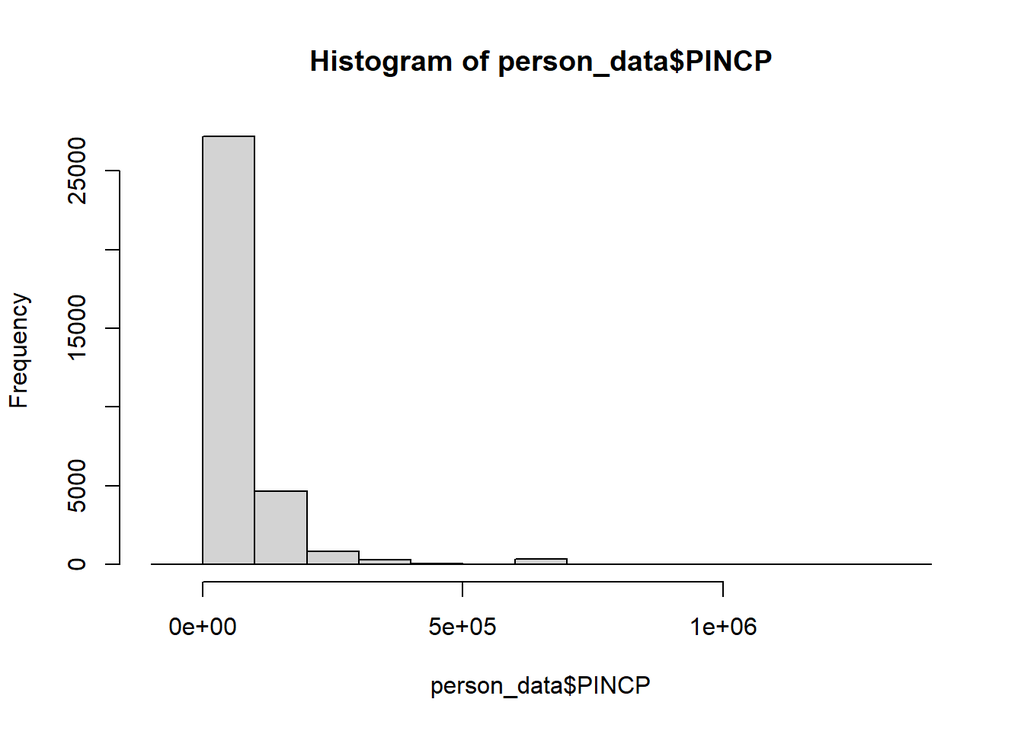

```r
hist(person_data$PINCP)
```

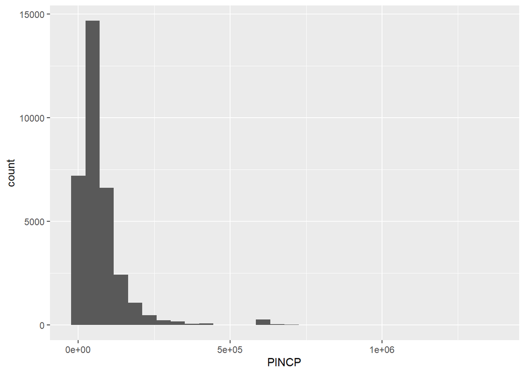

```r
ggplot(person_data, aes(x = PINCP)) + geom_histogram()
```

## The Summary statistics of the Work hours per week data.

Same steps for the Work hours per week data. I will skip explaining each step, except the calculated values and the illustration of each data’s histogram, as the only difference is variables.

```r
WKHP_summary <- summary(person_data$WKHP)
WKHP_summary
```

```
##    Min. 1st Qu.  Median    Mean 3rd Qu.    Max.
##     1.0    35.0    40.0    38.5    45.0    99.0
```

# The mean of the Work hours per week data.

```r
WKHP_summary["Mean"]
```

```
##     Mean
## 38.49804
```

The mean of the work hours per week data is 38.49804 hours.

# The standard deviation of the work hours per week data.

```r
sd(person_data$WKHP)
```

```
## [1] 12.76013
```

The standard deviation of the work hours per week data is 12.76013 hours.

# The 95-percent confidence interval for the work hours per week data.

```r
conf_int <- t.test(person_data$WKHP)

conf_int
```

```
##
##  One Sample t-test
##
## data:  person_data$WKHP
## t = 551.73, df = 33440, p-value < 2.2e-16
## alternative hypothesis: true mean is not equal to 0
## 95 percent confidence interval:
##  38.36127 38.63481
## sample estimates:
## mean of x
##  38.49804
```

The 95-percent confidence interval for the work hours per week data is from 38.36127 hours to 38.63481 hours.

# The interquartile range of the work hours per week data.

```r
WKHP_summary["1st Qu."]
```

```
## 1st Qu.
##      35
```

```r
WKHP_summary["3rd Qu."]
```

```
## 3rd Qu.
##      45
```

The interquartile range of the work hours per week data is from 35 hours to 45 hours.

# The historgram of the work hours per week data.

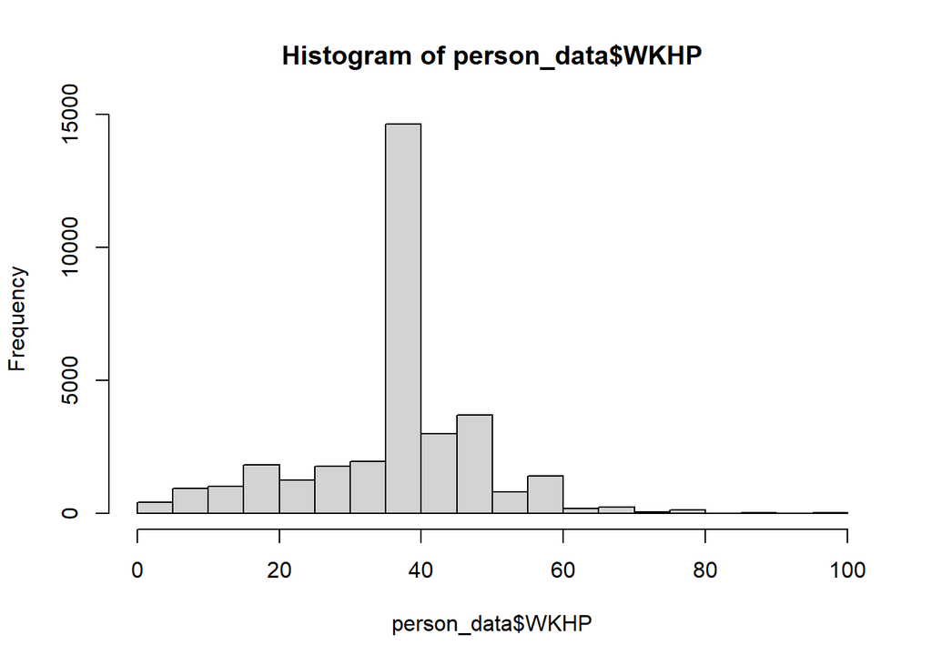

```r
hist(person_data$WKHP)
```

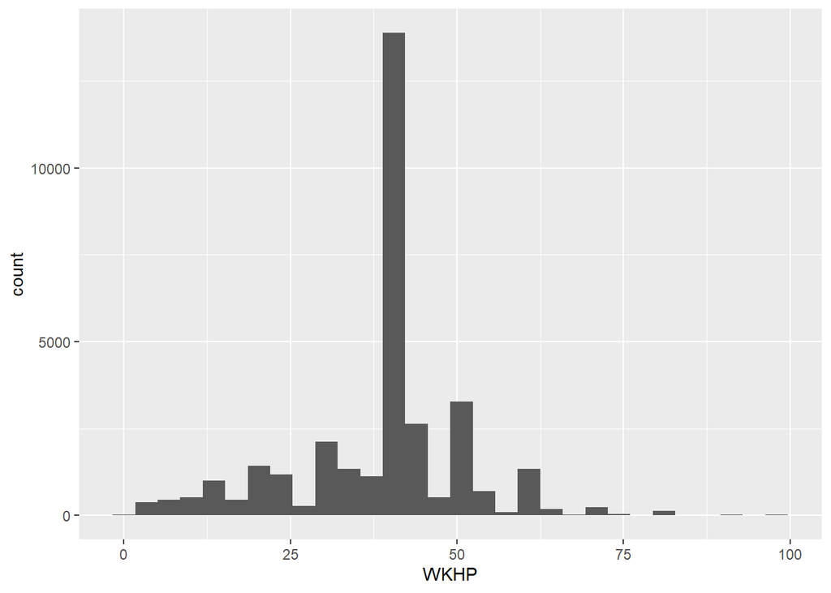

```r
ggplot(person_data, aes(x = WKHP)) + geom_histogram()
```

## The Summary statistics of the travel time to work data.

Same steps for the travel time to work data. I will skip explaining each step, except the calculated values and the illustration of each data’s histogram, as the only difference is variables.

```r
JWMNP_summary <- summary(person_data$JWMNP)
JWMNP_summary
```

```
##    Min. 1st Qu.  Median    Mean 3rd Qu.    Max.
##    1.00   15.00   25.00   30.57   40.00  144.00
```

# The mean of the travel time to work data.

```r
JWMNP_summary["Mean"]
```

```
##     Mean
## 30.56508
```

The mean of the travel time to work data is 30.56508 minutes.

# The standard deviation of the travel time to work data.

```r
sd(person_data$JWMNP)
```

```
## [1] 23.5714
```

The standard deviation of the travel time to work data is 23.5714 minutes.

# The 95-percent confidence interval for the travel time to work data.

```r
conf_int <- t.test(person_data$JWMNP)

conf_int
```

```
##
##  One Sample t-test
##
## data:  person_data$JWMNP
## t = 237.13, df = 33440, p-value < 2.2e-16
## alternative hypothesis: true mean is not equal to 0
## 95 percent confidence interval:
##  30.31244 30.81773
## sample estimates:
## mean of x
##  30.56508
```

The 95-percent confidence interval for the travel time to work data is from 30.31244 minutes to 30.81773 minutes.

# The interquartile range of the travel time to work data.

```r
JWMNP_summary["1st Qu."]
```

```
## 1st Qu.
##      15
```

```r
JWMNP_summary["3rd Qu."]
```

```
## 3rd Qu.
##      40
```

The interquartile range of the travel time to work data is from 15 minutes to 40 minutes.

# The historgram of the travel time to work data.

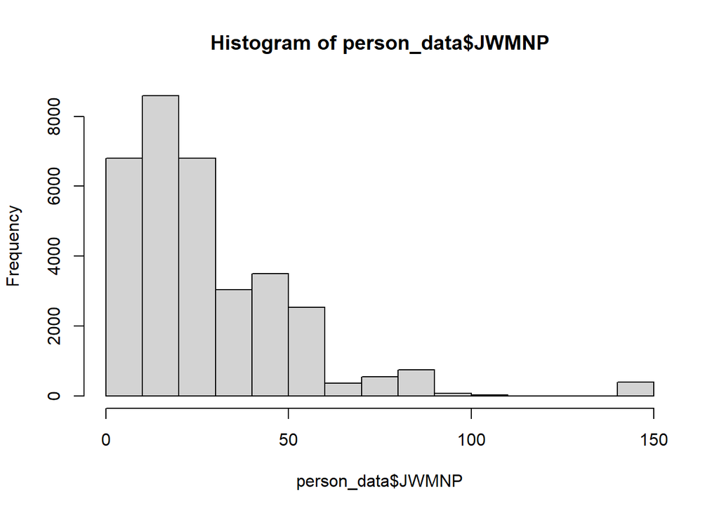

```r
hist(person_data$JWMNP)
```

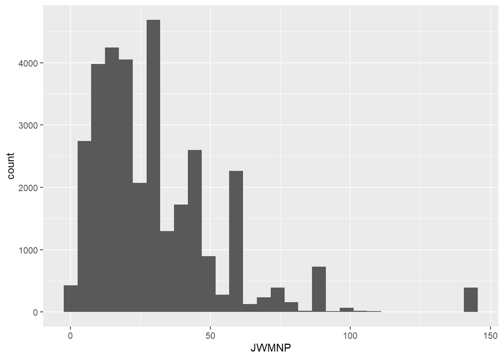

```r
ggplot(person_data, aes(x = JWMNP)) + geom_histogram()
```

Just as the histogram of the income data, the distribution is skewed to the right. Its shape looks closer to a negative binomial distribution or a Poisson distribution than to a normal distribution. Based on the bump in the number of people who report traveling almost 150 minutes, many outliers travel much more than other significant people.

## The categorical variables in the previous dataset.

There were three categorical variables in my person-level dataset in Massachusetts from the 1-year American Community Survey Sample from 2018.

1. Housing tenure (TEN) (categorical)
2. Sex (SEX) (categorical)
3. Workload level (workload) (categorical)

I will calculate the 95-percent confidence interval for each category’s proportion, only for the workload data. The workload data is the one I created from the first assignment, and the data on Housing tenure type and sex are either the information I am not interested in or less informative.

## The Summary statistics of the workload data.

# the possible categories of the workload data.

All the possible values of a categorical variable, Workload level, is as below.

```r
unique(person_data$workload)
```

```
## [1] "Light"  "Medium" "Heavy"
```

# the 95-percent confidence interval for the proportion of the population in each category.

First, I can use the t.test() function to get the 95-percent confidence interval for the Light category. As shown below, it is from 0.1219537 to 0.1290555.

```r
t.test(person_data$workload == "Light")
```

```
##
##  One Sample t-test
##
## data:  person_data$workload == "Light"
## t = 69.276, df = 33440, p-value < 2.2e-16
## alternative hypothesis: true mean is not equal to 0
## 95 percent confidence interval:
##  0.1219537 0.1290555
## sample estimates:
## mean of x
## 0.1255046
```

Same functions for other categories. The 95-percent confidence intervals for the Medium and the Heavy are from 0.5809775 to 0.5915353 and from 0.2833842 to 0.2930938 each.

```r
t.test(person_data$workload == "Medium")
```

```
##
##  One Sample t-test
##
## data:  person_data$workload == "Medium"
## t = 217.68, df = 33440, p-value < 2.2e-16
## alternative hypothesis: true mean is not equal to 0
## 95 percent confidence interval:
##  0.5809775 0.5915353
## sample estimates:
## mean of x
## 0.5862564
```

```r
t.test(person_data$workload == "Heavy")
```

```
##
##  One Sample t-test
##
## data:  person_data$workload == "Heavy"
## t = 116.37, df = 33440, p-value < 2.2e-16
## alternative hypothesis: true mean is not equal to 0
## 95 percent confidence interval:
##  0.2833842 0.2930938
## sample estimates:
## mean of x
##  0.288239
```